# 2. Creating a sampled dataset

This notebook illustrates:

1. Sampling a BigQuery dataset to create datasets for ML
2. Preprocessing with Pandas

```python
!sudo chown -R jupyter:jupyter /home/jupyter/training-data-analyst
```

```python
# Ensure the right version of Tensorflow is installed.
!pip freeze | grep tensorflow==2.1
```

```python
# change these to try this notebook out
BUCKET = 'qwiklabs-gcp-03-9cef999001cf'
PROJECT = 'qwiklabs-gcp-03-9cef999001cf'
REGION = 'us-central1'
```

```python
import os
os.environ['BUCKET'] = BUCKET
os.environ['PROJECT'] = PROJECT
os.environ['REGION'] = REGION
```

```python
%%bash
if ! gsutil ls | grep -q gs://${BUCKET}/; then
  gsutil mb -l ${REGION} gs://${BUCKET}
fi
```

## Create ML dataset by sampling using BigQuery

Let's sample the BigQuery data to create smaller datasets.

```python
# Create SQL query using natality data after the year 2000
from google.cloud import bigquery
query = """
SELECT
  weight_pounds,
  is_male,
  mother_age,
  plurality,
  gestation_weeks,
  FARM_FINGERPRINT(CONCAT(CAST(YEAR AS STRING), CAST(month AS STRING))) AS hashmonth
FROM
  publicdata.samples.natality
WHERE year > 2000
"""
```

There are only a limited number of years and months in the dataset. Let's see what the hashmonths are.

```python
# Call BigQuery but GROUP BY the hashmonth and see number of records for each group to enable us to get the correct train and evaluation percentages
df = bigquery.Client().query("SELECT hashmonth, COUNT(weight_pounds) AS num_babies FROM (" + query + ") GROUP BY hashmonth").to_dataframe()
print("There are {} unique hashmonths.".format(len(df)))
df.head()
```

```
There are 96 unique hashmonths.
```

|  | hashmonth | num_babies |
| --- | --- | --- |
| 0 | -1403073183891835564 | 351299 |
| 1 | 1451354159195218418 | 334485 |
| 2 | 3545707052733304728 | 327823 |
| 3 | 2246942437170405963 | 330315 |
| 4 | -9183605629983195042 | 329975 |

Here's a way to get a well distributed portion of the data in such a way that the test and train sets do not overlap:

```python
# Added the RAND() so that we can now subsample from each of the hashmonths to get approximately the record counts we want
trainQuery = "SELECT * FROM (" + query + ") WHERE ABS(MOD(hashmonth, 4)) < 3 AND RAND() < 0.0005"
evalQuery = "SELECT * FROM (" + query + ") WHERE ABS(MOD(hashmonth, 4)) = 3 AND RAND() < 0.0005"
traindf = bigquery.Client().query(trainQuery).to_dataframe()
evaldf = bigquery.Client().query(evalQuery).to_dataframe()
print("There are {} examples in the train dataset and {} in the eval dataset".format(len(traindf), len(evaldf)))
```

```
There are 13366 examples in the train dataset and 3331 in the eval dataset
```

## Preprocess data using Pandas

Let's add extra rows to simulate the lack of ultrasound. In the process, we'll also change the plurality column to be a string.

```python
traindf.head()
```

|  | weight_pounds | is_male | mother_age | plurality | gestation_weeks | hashmonth |
| --- | --- | --- | --- | --- | --- | --- |
| 0 | 6.999677 | False | 24 | 1 | 39.0 | 3095933535584005890 |
| 1 | 9.810571 | False | 37 | 1 | 40.0 | 3095933535584005890 |
| 2 | 7.125340 | True | 34 | 1 | 36.0 | 3095933535584005890 |
| 3 | 7.874912 | False | 22 | 1 | 38.0 | 3095933535584005890 |
| 4 | 8.124034 | True | 21 | 1 | 40.0 | 3095933535584005890 |

Also notice that there are some very important numeric fields that are missing in some rows (the count in Pandas doesn't count missing data)

```python
# Let's look at a small sample of the training data
traindf.describe()
```

|  | weight_pounds | mother_age | plurality | gestation_weeks | hashmonth |
| --- | --- | --- | --- | --- | --- |
| count | 13357.000000 | 13366.000000 | 13366.000000 | 13286.000000 | 1.336600e+04 |
| mean | 7.228813 | 27.284229 | 1.032620 | 38.594912 | 3.700789e+17 |
| std | 1.327310 | 6.150058 | 0.189862 | 2.573830 | 5.202638e+18 |
| min | 0.562179 | 12.000000 | 1.000000 | 18.000000 | -9.183606e+18 |
| 25% | 6.563162 | 22.000000 | 1.000000 | 38.000000 | -3.340563e+18 |
| 50% | 7.312733 | 27.000000 | 1.000000 | 39.000000 | -2.605984e+17 |
| 75% | 8.062305 | 32.000000 | 1.000000 | 40.000000 | 5.896568e+18 |
| max | 12.687603 | 50.000000 | 5.000000 | 47.000000 | 8.599690e+18 |

```python
# It is always crucial to clean raw data before using in ML, so we have a preprocessing step
import pandas as pd
def preprocess(df):
  # clean up data we don't want to train on
  # in other words, users will have to tell us the mother's age
  # otherwise, our ML service won't work.
  # these were chosen because they are such good predictors
  # and because these are easy enough to collect
  df = df[df.weight_pounds > 0]
  df = df[df.mother_age > 0]
  df = df[df.gestation_weeks > 0]
  df = df[df.plurality > 0]

  # modify plurality field to be a string
  twins_etc = dict(zip([1,2,3,4,5],
                   ['Single(1)', 'Twins(2)', 'Triplets(3)', 'Quadruplets(4)', 'Quintuplets(5)']))
  df['plurality'].replace(twins_etc, inplace=True)

  # now create extra rows to simulate lack of ultrasound
  nous = df.copy(deep=True)
  nous.loc[nous['plurality'] != 'Single(1)', 'plurality'] = 'Multiple(2+)'
  nous['is_male'] = 'Unknown'

  return pd.concat([df, nous])
```

```python
traindf.head()# Let's see a small sample of the training data now after our preprocessing
traindf = preprocess(traindf)
evaldf = preprocess(evaldf)
traindf.head()
```

|  | weight_pounds | is_male | mother_age | plurality | gestation_weeks | hashmonth |
| --- | --- | --- | --- | --- | --- | --- |
| 0 | 6.999677 | False | 24 | Single(1) | 39.0 | 3095933535584005890 |
| 1 | 9.810571 | False | 37 | Single(1) | 40.0 | 3095933535584005890 |
| 2 | 7.125340 | True | 34 | Single(1) | 36.0 | 3095933535584005890 |
| 3 | 7.874912 | False | 22 | Single(1) | 38.0 | 3095933535584005890 |
| 4 | 8.124034 | True | 21 | Single(1) | 40.0 | 3095933535584005890 |

```python
traindf.tail()
```

|  | weight_pounds | is_male | mother_age | plurality | gestation_weeks | hashmonth |
| --- | --- | --- | --- | --- | --- | --- |
| 13361 | 7.008495 | Unknown | 25 | Single(1) | 38.0 | -774501970389208065 |
| 13362 | 7.469261 | Unknown | 38 | Single(1) | 39.0 | -774501970389208065 |
| 13363 | 7.374463 | Unknown | 29 | Single(1) | 40.0 | -774501970389208065 |
| 13364 | 7.407532 | Unknown | 30 | Single(1) | 39.0 | -774501970389208065 |
| 13365 | 4.687028 | Unknown | 32 | Single(1) | 37.0 | -774501970389208065 |

```python
# Describe only does numeric columns, so you won't see plurality
traindf.describe()
```

|  | weight_pounds | mother_age | gestation_weeks | hashmonth |
| --- | --- | --- | --- | --- |
| count | 26560.000000 | 26560.000000 | 26560.000000 | 2.656000e+04 |
| mean | 7.230209 | 27.287199 | 38.596536 | 3.745941e+17 |
| std | 1.326325 | 6.144002 | 2.571003 | 5.203716e+18 |
| min | 0.562179 | 12.000000 | 18.000000 | -9.183606e+18 |
| 25% | 6.563162 | 22.000000 | 38.000000 | -3.340563e+18 |
| 50% | 7.312733 | 27.000000 | 39.000000 | -2.605984e+17 |
| 75% | 8.062305 | 32.000000 | 40.000000 | 5.896568e+18 |
| max | 12.687603 | 50.000000 | 47.000000 | 8.599690e+18 |

```python
traindf.info()
```

```
<class 'pandas.core.frame.DataFrame'>
Int64Index: 26560 entries, 0 to 13365
Data columns (total 6 columns):
weight_pounds      26560 non-null float64
is_male            26560 non-null object
mother_age         26560 non-null int64
plurality          26560 non-null object
gestation_weeks    26560 non-null float64
hashmonth          26560 non-null int64
dtypes: float64(2), int64(2), object(2)
memory usage: 1.4+ MB
```

```python
traindf.isnull().sum()
```

```
weight_pounds      0
is_male            0
mother_age         0
plurality          0
gestation_weeks    0
hashmonth          0
dtype: int64
```

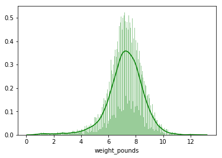

```python
import seaborn as sns

sns.distplot(traindf['weight_pounds'], color='g', bins=300, hist_kws={'alpha': 0.4});
```

```python
df_num = traindf.select_dtypes(include = ['float64', 'int64'])
df_num.head()
```

|  | weight_pounds | mother_age | gestation_weeks | hashmonth |
| --- | --- | --- | --- | --- |
| 0 | 6.999677 | 24 | 39.0 | 3095933535584005890 |
| 1 | 9.810571 | 37 | 40.0 | 3095933535584005890 |
| 2 | 7.125340 | 34 | 36.0 | 3095933535584005890 |
| 3 | 7.874912 | 22 | 38.0 | 3095933535584005890 |
| 4 | 8.124034 | 21 | 40.0 | 3095933535584005890 |

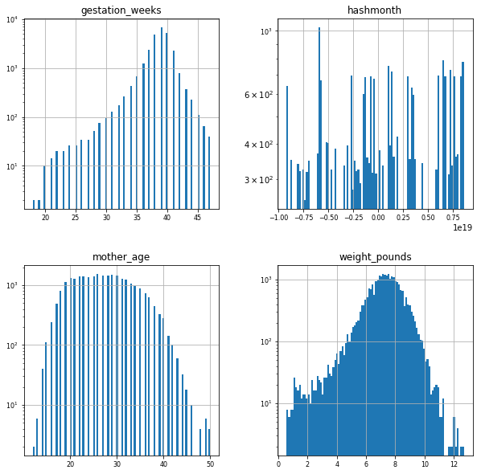

```python
df_num.hist(figsize=(10, 10), bins=100, xlabelsize=8, ylabelsize=8 , log = True); # ; avoid having the matplotlib verbose informations
```

```python
df_num_corr = df_num.corr()['weight_pounds'][:-1] # -1 because the latest row is SalePrice
golden_features_list = df_num_corr[abs(df_num_corr) > -9].sort_values(ascending=False)
print("There is {} strongly correlated values with weight_pounds:\n{}".format(len(golden_features_list), golden_features_list))
```

```
There is 3 strongly correlated values with weight_pounds:
weight_pounds      1.000000
gestation_weeks    0.542021
mother_age         0.077851
Name: weight_pounds, dtype: float64
```

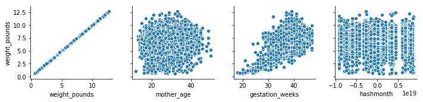

```python
import matplotlib.pyplot as plt

plt.figure(figsize =(10,10))
for i in range(0, len(df_num.columns), 5):
    sns.pairplot(data=df_num,
                x_vars=df_num.columns[i:i+5],
                y_vars=['weight_pounds'])
```

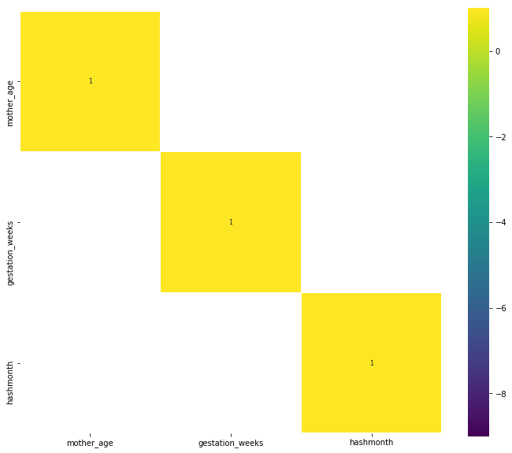

```python
corr = df_num.drop('weight_pounds', axis=1).corr() # We already examined SalePrice correlations
plt.figure(figsize=(12, 10))

sns.heatmap(corr[(corr >= 0.1) | (corr <= -0.4)],
            cmap='viridis', vmax=1.0, vmin=-9.0, linewidths=0.1,
            annot=True, annot_kws={"size": 8}, square=True);
```

## Write out

In the final versions, we want to read from files, not Pandas dataframes. So, write the Pandas dataframes out as CSV files. Using CSV files gives us the advantage of shuffling during read. This is important for distributed training because some workers might be slower than others, and shuffling the data helps prevent the same data from being assigned to the slow workers.

```python
quantitative_features_list = [
'is_male',
'mother_age',
'gestation_weeks',
'hashmonth']
df_quantitative_values = traindf[quantitative_features_list]
df_quantitative_values.head()
```

|  | is_male | mother_age | gestation_weeks | hashmonth |
| --- | --- | --- | --- | --- |
| 0 | False | 24 | 39.0 | 3095933535584005890 |
| 1 | False | 37 | 40.0 | 3095933535584005890 |
| 2 | True | 34 | 36.0 | 3095933535584005890 |
| 3 | False | 22 | 38.0 | 3095933535584005890 |
| 4 | True | 21 | 40.0 | 3095933535584005890 |

```python
features_to_analyse = [x for x in quantitative_features_list if x in golden_features_list]
features_to_analyse.append('weight_pounds')
features_to_analyse
```

```
['mother_age', 'gestation_weeks', 'weight_pounds']
```

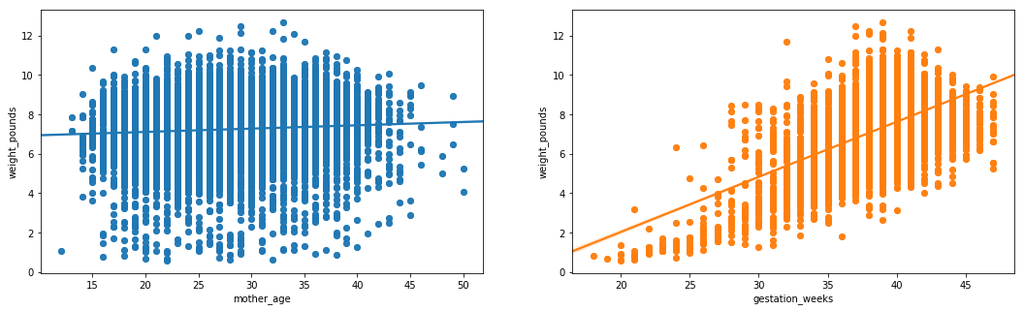

```python
fig, ax = plt.subplots(round(len(features_to_analyse) / 3), 2, figsize = (18, 5))

for i, ax in enumerate(fig.axes):
    if i < len(features_to_analyse) - 1:
        sns.regplot(x=features_to_analyse[i],y='weight_pounds', data=traindf[features_to_analyse], ax=ax)
```

```python
categorical_features = ['is_male' ,'plurality', 'weight_pounds']
df_categ = traindf[categorical_features]
df_categ.head()
```

|  | is_male | plurality | weight_pounds |
| --- | --- | --- | --- |
| 0 | False | Single(1) | 6.999677 |
| 1 | False | Single(1) | 9.810571 |
| 2 | True | Single(1) | 7.125340 |
| 3 | False | Single(1) | 7.874912 |
| 4 | True | Single(1) | 8.124034 |

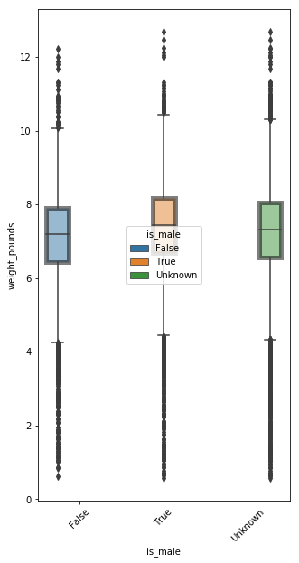

```python
plt.figure(figsize = (5, 10))
ax = sns.boxplot(x='is_male', y='weight_pounds', data=df_categ, hue="is_male")
plt.setp(ax.artists, alpha=.5, linewidth=5, edgecolor="k")
plt.xticks(rotation=45)
```

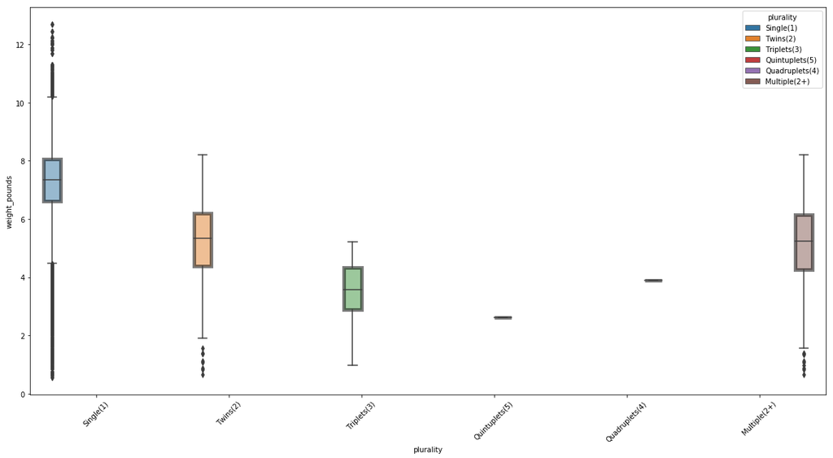

```python
plt.figure(figsize = (20, 10))
ax = sns.boxplot(x='plurality', y='weight_pounds', data=df_categ, hue="plurality")
plt.setp(ax.artists, alpha=.5, linewidth=5, edgecolor="k")
plt.xticks(rotation=45)
```

```python
traindf.to_csv('train.csv', index=False, header=False)
evaldf.to_csv('eval.csv', index=False, header=False)
```

```python
%%bash
wc -l *.csv
head *.csv
tail *.csv
```

```
   6596 eval.csv
  26560 train.csv
  33156 total
==> eval.csv <==
7.43839671988,True,18,Single(1),40.0,-1639186255933990135
7.936641432,True,22,Single(1),39.0,-1639186255933990135
9.37405538024,True,33,Single(1),39.0,-6141045177192779423
7.1429772888,False,22,Single(1),41.0,8904940584331855459
8.498820200099999,True,23,Single(1),40.0,3182182455926341111
8.23206086308,False,22,Single(1),39.0,-1891060869255459203
8.000575487979999,False,39,Single(1),39.0,-6782146986770280327
7.50012615324,False,33,Single(1),38.0,6365946696709051755
7.71176992476,False,28,Single(1),41.0,6392072535155213407
5.55344437978,True,20,Single(1),39.0,-6141045177192779423

==> train.csv <==
6.9996768185,False,24,Single(1),39.0,3095933535584005890
9.810570659,False,37,Single(1),40.0,3095933535584005890
7.12534030784,True,34,Single(1),36.0,3095933535584005890
7.87491199864,False,22,Single(1),38.0,3095933535584005890
8.1240343547,True,21,Single(1),40.0,3095933535584005890
7.87491199864,True,32,Single(1),38.0,3095933535584005890
7.7492485093,False,27,Single(1),33.0,3095933535584005890
6.8122838958,False,25,Single(1),40.0,3095933535584005890
6.686620406459999,True,16,Single(1),37.0,3095933535584005890
7.7382253962,True,24,Single(1),40.0,3095933535584005890
==> eval.csv <==
7.3744626639,Unknown,36,Single(1),39.0,6365946696709051755
6.7681914434,Unknown,30,Single(1),36.0,-1866590652208008467
8.6751900097,Unknown,31,Single(1),39.0,-6910174677251748583
6.3162438063,Unknown,32,Single(1),39.0,6365946696709051755
8.18576378806,Unknown,38,Single(1),38.0,1088037545023002395
7.43839671988,Unknown,31,Single(1),40.0,-7146494315947640619
6.7681914434,Unknown,29,Single(1),39.0,74931465496927487
5.37486994756,Unknown,16,Single(1),35.0,-6244544205302024223
6.9996768185,Unknown,38,Single(1),40.0,-7517141034410775575
6.87621795178,Unknown,29,Single(1),39.0,-4740473290291881219

==> train.csv <==
5.8753192823,Unknown,21,Single(1),30.0,-774501970389208065
7.25100379718,Unknown,30,Single(1),39.0,-774501970389208065
7.62578964258,Unknown,32,Single(1),41.0,-774501970389208065
9.37626000286,Unknown,19,Single(1),37.0,-774501970389208065
8.3224503905,Unknown,19,Single(1),37.0,-774501970389208065
7.00849530898,Unknown,25,Single(1),38.0,-774501970389208065
7.46926143656,Unknown,38,Single(1),39.0,-774501970389208065
7.3744626639,Unknown,29,Single(1),40.0,-774501970389208065
7.4075320032,Unknown,30,Single(1),39.0,-774501970389208065
4.68702769012,Unknown,32,Single(1),37.0,-774501970389208065
```

Copyright 2020 Google Inc. Licensed under the Apache License, Version 2.0 (the "License"); you may not use this file except in compliance with the License. You may obtain a copy of the License at http://www.apache.org/licenses/LICENSE-2.0 Unless required by applicable law or agreed to in writing, software distributed under the License is distributed on an "AS IS" BASIS, WITHOUT WARRANTIES OR CONDITIONS OF ANY KIND, either express or implied. See the License for the specific language governing permissions and limitations under the License